# Quick and Dirty Analysis of Dataset

The goal of this notebook is to perform a quick analysis of the data to see if our hypothesis is explorable or not. We begin by importing necessary libraries and importing data. Our data is from [data.gov](https://data.gov.sg/dataset/resale-flat-prices).

```r
library(tidyverse)
library(lubridate)
library(ggplot2)
prices <- read_csv('csv/final.csv')
```

[output not shown]

Let’s see what towns are captured in our dataset.

```r
unique(prices$town)
```

```
 [1] "ANG MO KIO"      "BEDOK"           "BISHAN"          "BUKIT BATOK"     "BUKIT MERAH"     "BUKIT TIMAH"
 [7] "CENTRAL AREA"    "CHOA CHU KANG"   "CLEMENTI"        "GEYLANG"         "HOUGANG"         "JURONG EAST"
[13] "JURONG WEST"     "KALLANG/WHAMPOA" "MARINE PARADE"   "QUEENSTOWN"      "SENGKANG"        "SERANGOON"
[19] "TAMPINES"        "TOA PAYOH"       "WOODLANDS"       "YISHUN"          "LIM CHU KANG"    "SEMBAWANG"
[25] "BUKIT PANJANG"   "PASIR RIS"       "PUNGGOL"
```

We now need to decide on a few towns we wish to analyse over the years. We decided to use the following towns as *“control”* towns:

- Marine Parade
- Hougang
- Woodlands

We chose these due to them being quite far from the Downtown line. These locations also haven’t had any new MRT stations nearby in a very long time, which should reduce the possibility of unintended price increases.

We chose the following town to be our *“experimental”* towns:

- Tampines

These tend to have quite a number of HDB blocks around them, which is what our dataset contains. We now need to extract the relevant components of our dataset and plot facet plots of them. For the purpose of our analysis, we use 4-room flats as they are the most commonly purchased/sold units.

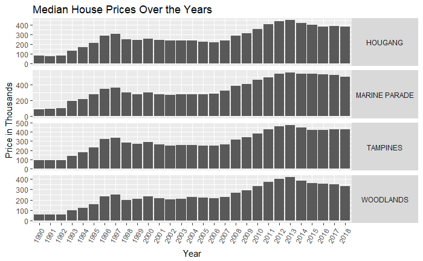

```r
towns <- prices %>%
  filter(town == "MARINE PARADE" | town == "HOUGANG" | town == "WOODLANDS" | town == "TAMPINES") %>%
  filter(flat_type == "4 ROOM") %>%
  mutate(year = substr(month, 1, 4)) %>%
  mutate(resale_price = resale_price / 1000)
ggplot(towns, aes(x=year, y=resale_price)) +
  geom_bar(stat="summary", fun.y = "median") +
  facet_grid(town ~ ., scales="free_y") +
  theme(strip.text.y = element_text(angle = 0), axis.text.x = element_text(angle = 60, hjust = 1)) +
  ylab("Price in Thousands") + xlab("Year") +
  ggtitle("Median House Prices Over the Years") +
  guides(fill=FALSE)
```

As we can see, both our control and our experimental towns have the same trends. Hence, we might need to increase the granularity of our analysis. We therefore need to geocode our data so we can properly restrict them to smaller zones.

```r
toGeocode <- prices %>%
  filter(flat_type == "4 ROOM") %>%
  mutate(year = substr(month, 1, 4)) %>%
  mutate(resale_price = resale_price / 1000) %>%
  mutate(location = paste0(block, " ", street_name))

toGeocode.unique <- toGeocode %>%
  group_by(location) %>%
  summarise(count = n())
#write_csv(toGeocode.unique, "csv/toGeocode.csv")
geocodedLocations <- read_csv("csv/geocoded.csv")
geocodedPrices <- left_join(geocodedLocations, toGeocode, by = c("location" = "location")) %>%
  filter(lat != "unknown") %>%
  mutate(lat = as.numeric(lat)) %>%
  mutate(lon = as.numeric(long))
```

```r
library(sf)
buffers <- st_read("shp/All Stations Buffers.shp")
buffers1km <- st_read("shp/All Stations Buffers 1KM.shp")
buffers15km <- st_read("shp/All Stations Buffers 1.5KM.shp")
```

```
replacing null geometries with empty geometries
Simple feature collection with 208 features and 11 fields (with 37 geometries empty)
geometry type:  GEOMETRY
dimension:      XY
bbox:           xmin: 103.6265 ymin: 1.237873 xmax: 103.9992 ymax: 1.463107
epsg (SRID):    4326
proj4string:    +proj=longlat +datum=WGS84 +no_defs
```

```r
priceShapes <- st_as_sf(geocodedPrices, coords = c("lon", "lat"), crs = 4326)
#plot(buffers)
#plot(priceShapes, add = T)
intersection = st_intersection(priceShapes, buffers)
```

```
although coordinates are longitude/latitude, st_intersection assumes that they are planar
```

Now that we have the intersection, we can re-plot the graphs above with higher granularity.

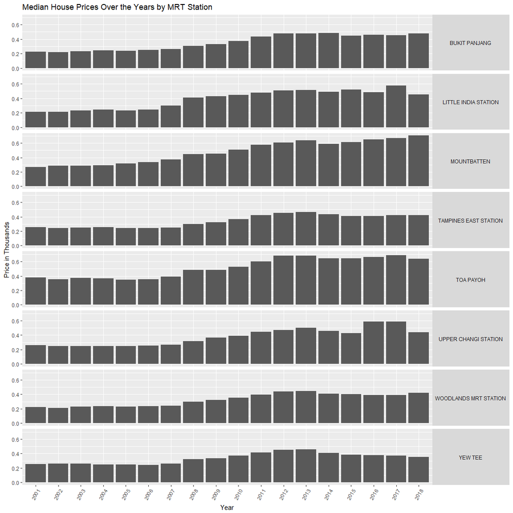

```r
toPlot <- intersection %>%
  filter(NAME == "UPPER CHANGI STATION" | NAME == "MOUNTBATTEN" | NAME == "YEW TEE" | NAME == "WOODLANDS MRT STATION" | NAME == "TOA PAYOH" | NAME == "BUKIT PANJANG" | NAME == "TAMPINES EAST STATION" | NAME == "LITTLE INDIA STATION") %>%
  filter(flat_type == "4 ROOM") %>%
  filter(year > 2000) %>%
  mutate(year = substr(month, 1, 4)) %>%
  mutate(resale_price = resale_price / 1000)
ggplot(toPlot, aes(x=year, y=resale_price)) +
  geom_bar(stat="summary", fun.y = "median") +
  facet_grid(NAME ~ .) +
  theme(strip.text.y = element_text(angle = 0), axis.text.x = element_text(angle = 60, hjust = 1)) +
  ylab("Price in Thousands") + xlab("Year") +
  ggtitle("Median House Prices Over the Years by MRT Station") +
  guides(fill=FALSE)
```

We now test the Circle Line (CCL) stations instead:

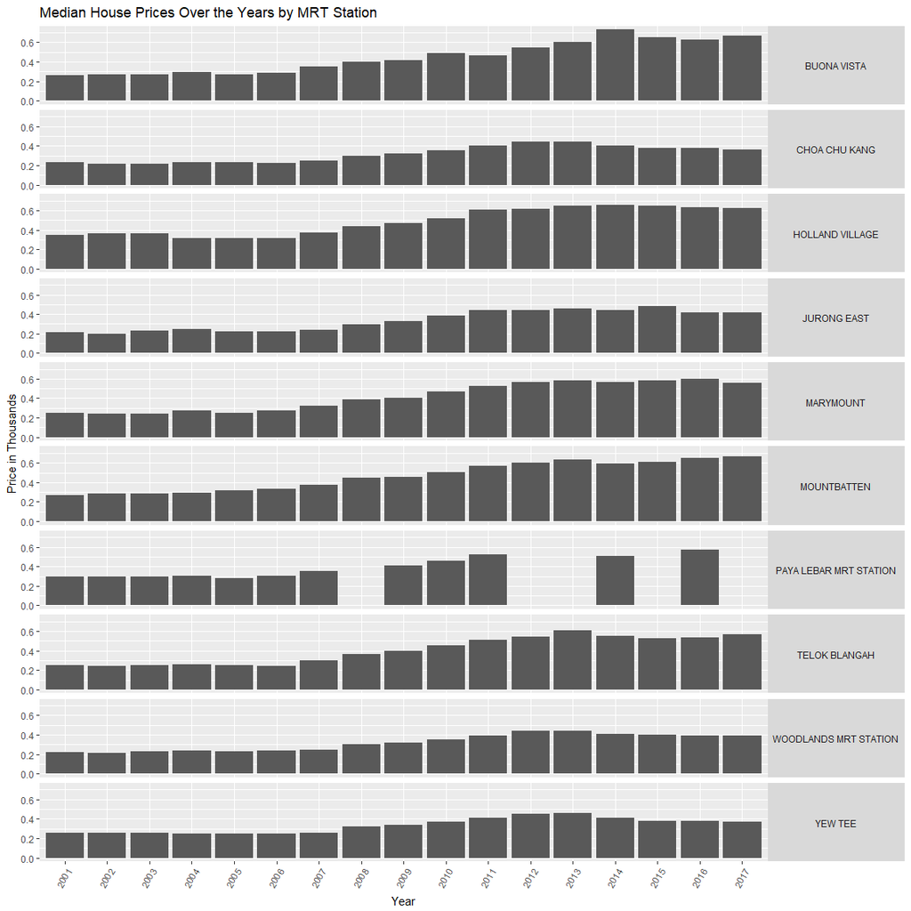

```r
toPlot <- intersection %>%
  filter(NAME == "MOUNTBATTEN" | NAME == "YEW TEE" | NAME == "WOODLANDS MRT STATION" | NAME == "HOLLAND VILLAGE" | NAME == "TELOK BLANGAH" | NAME == "JURONG EAST" | NAME == "PAYA LEBAR MRT STATION" | NAME == "BUONA VISTA" | NAME == "MARYMOUNT" | NAME == "CHOA CHU KANG") %>%
  filter(flat_type == "4 ROOM") %>%
  filter(year > 2000) %>%
  filter(year < 2018) %>%
  mutate(year = substr(month, 1, 4)) %>%
  mutate(resale_price = resale_price / 1000)
ggplot(toPlot, aes(x=year, y=resale_price)) +
  geom_bar(stat="summary", fun.y = "median") +
  facet_grid(NAME ~ .) +
  theme(strip.text.y = element_text(angle = 0), axis.text.x = element_text(angle = 60, hjust = 1)) +
  ylab("Price in Thousands") + xlab("Year") +
  ggtitle("Median House Prices Over the Years by MRT Station") +
  guides(fill=FALSE)
```

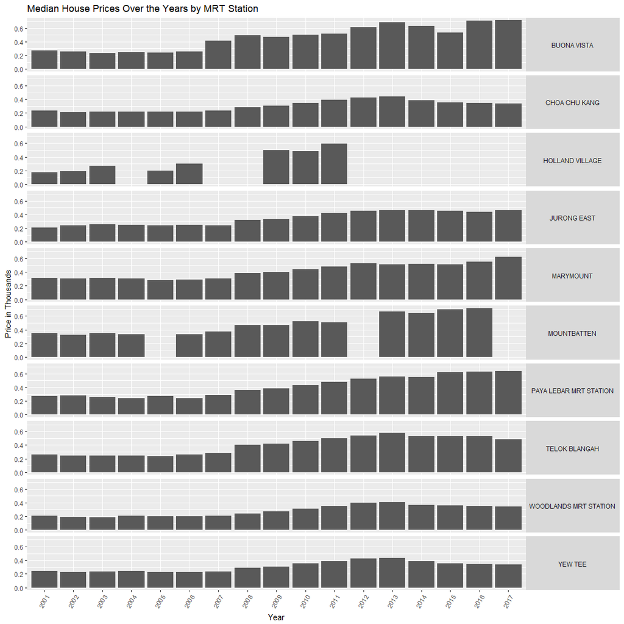

```r
toPlot1km <- intersection1km %>%
  filter(NAME == "MOUNTBATTEN" | NAME == "YEW TEE" | NAME == "WOODLANDS MRT STATION" | NAME == "HOLLAND VILLAGE" | NAME == "TELOK BLANGAH" | NAME == "JURONG EAST" | NAME == "PAYA LEBAR MRT STATION" | NAME == "BUONA VISTA" | NAME == "MARYMOUNT" | NAME == "CHOA CHU KANG") %>%
  filter(flat_type == "4 ROOM") %>%
  filter(year > 2000) %>%
  filter(year < 2018) %>%
  mutate(year = substr(month, 1, 4)) %>%
  mutate(resale_price = resale_price / 1000)
ggplot(toPlot1km, aes(x=year, y=resale_price)) +
  geom_bar(stat="summary", fun.y = "median") +
  facet_grid(NAME ~ .) +
  theme(strip.text.y = element_text(angle = 0), axis.text.x = element_text(angle = 60, hjust = 1)) +
  ylab("Price in Thousands") + xlab("Year") +
  ggtitle("Median House Prices Over the Years by MRT Station") +
  guides(fill=FALSE)
```

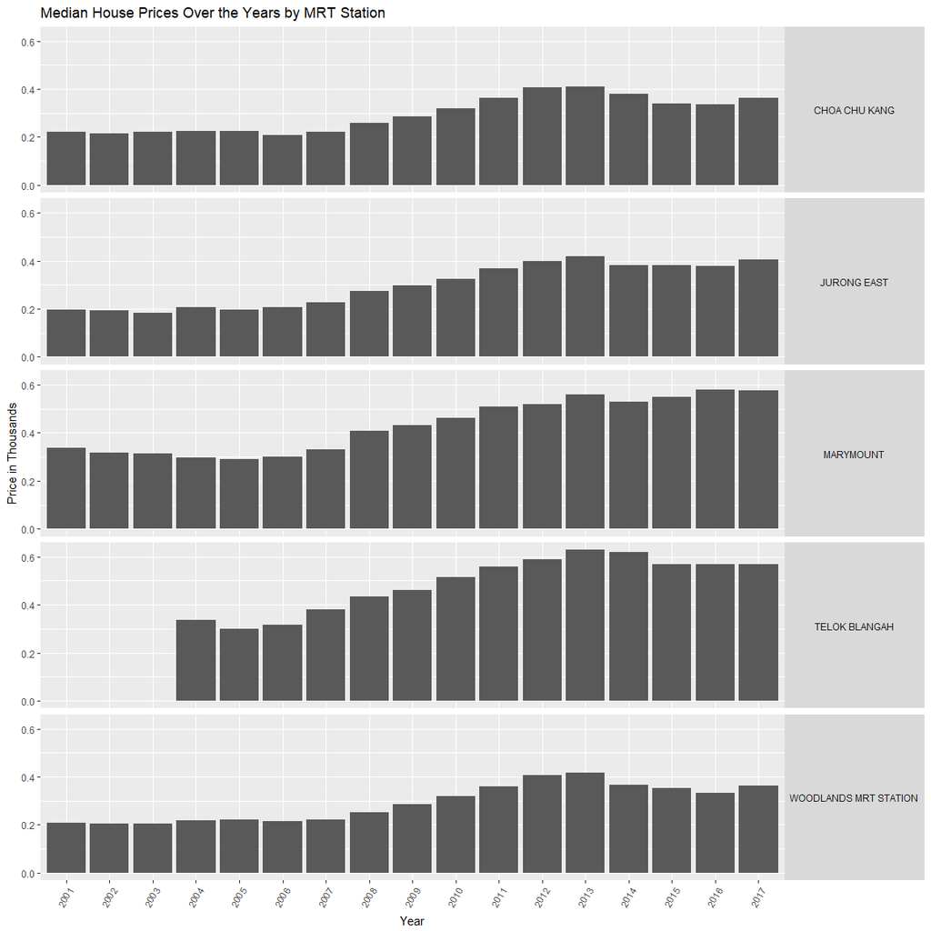

```r
toPlot15km <- intersection15km %>%
  filter(NAME == "MOUNTBATTEN" | NAME == "YEW TEE" | NAME == "WOODLANDS MRT STATION" | NAME == "HOLLAND VILLAGE" | NAME == "TELOK BLANGAH" | NAME == "JURONG EAST" | NAME == "PAYA LEBAR MRT STATION" | NAME == "BUONA VISTA" | NAME == "MARYMOUNT" | NAME == "CHOA CHU KANG") %>%
  filter(flat_type == "4 ROOM") %>%
  filter(year > 2000) %>%
  filter(year < 2018) %>%
  mutate(year = substr(month, 1, 4)) %>%
  mutate(resale_price = resale_price / 1000)
ggplot(toPlot15km, aes(x=year, y=resale_price)) +
  geom_bar(stat="summary", fun.y = "median") +
  facet_grid(NAME ~ .) +
  theme(strip.text.y = element_text(angle = 0), axis.text.x = element_text(angle = 60, hjust = 1)) +
  ylab("Price in Thousands") + xlab("Year") +
  ggtitle("Median House Prices Over the Years by MRT Station") +
  guides(fill=FALSE)
```

```r
library(tidyverse)
library(lubridate)
library(ggplot2)
library(sf)
subzones <- st_read('kml/MP14_SUBZONE_WEB_PL.kml')
buffers <- st_read("shp/CCLNEL Multiring Buffer.shp") %>%
  mutate(unique = paste0(OBJECTID, ".", distance))
priceShapes <- st_read("shp/CCLNEL Intersection.shp") %>%
  mutate(unique = paste0(OBJECTID, ".", distance)) %>%
  mutate(psm = resale_p_1 / floor_area) %>%
  mutate(year = as.numeric(substring(month, 1, 4))) %>%
  mutate(flat_type = replace(flat_type, flat_type == "MULTI GENERATION", "MULTI-GENERATION"))
```

```
NAs introduced by coercion
```

```r
priceShapes.unique <- priceShapes %>%
  group_by(unique) %>%
  summarise(median(resale_pri)) %>%
  select(unique, median_price = "median(resale_pri)")
```

A quick look on what we can expect in our analysis for NEL and CCL.

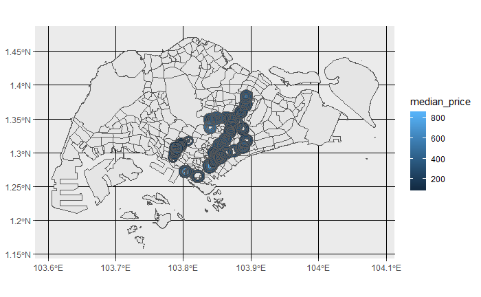

```r
buffers.medians <- buffers %>%
  left_join(as.data.frame(priceShapes.unique), by = c('unique' = 'unique')) %>%
  drop_na(median_price) %>%
  mutate(median_price = median_price / 1000)# %>%
  #mutate(median_price = median_price / max(median_price))
ggplot() +
  geom_sf(subzones, mapping = aes()) +
  geom_sf(buffers.medians, mapping = aes(fill = median_price))# +
```

```r
  #scale_fill_brewer(type="seq", palette = 5)
```